# Advanced Graphics

Xu Liu

# 1 Lattice

## 1.1 An Overview of the Lattice Package

- In the early 1990s, Richard Becker and William Cleveland (two researchers at Bell Labs) built a revolutionary new system for displaying data called Trellis graphics. And the lattice package is an implementation of Trellis graphics.
- The lattice package provides a different way to plot graphics in R. Lattice graphics are created with different functions, and have different options. These functions make it easy to do some things that are hard to do with standard graphics, such as plotting multiple plots on the same page or superimposing plots. Additionally, most lattice functions can produce clean, readable output by default.
- The real strength of the lattice package is in splitting a chart into different panels (shown in a grid), or groups (shown with different colors or symbols) using a conditioning or grouping variable.

### 1.1.1 How Lattice Works

- Lattice graphics consist of one or more rectangular drawing areas called panels. The data assigned to each panel is referred to as a packet. Lattice functions work by calling one or more panel functions, which actually plot the packets within panels. Here is what typically happens in a lattice session:
  1. The end user calls a high-level lattice plotting function.
  2. The lattice function examines the calling arguments and default parameters, assembles a lattice object, and returns the object.
  3. The user calls `print.lattice()` or `plot.lattice()` with the lattice object as an argument. (This typically happens automatically on the R console.)
  4. The function `plot.lattice()` sets up the matrix of panels, assigns packets to different panels and and then calls the panel function specified in the lattice object to draw the individual panels.
- Lattice graphics are extremely modular. They share many high-level functions (like plot.lattice) and low-level functions (like panel.axis, which draws axes). This means that they share many common arguments. It also means that you can customize the appearance of lattice graphics by creating substitute components.

Data sets in lattice package:

| Dataset | Description |
| --- | --- |
| USMortality | Mortality Rates in US by Cause and Gender |
| USRegionalMortality | Mortality Rates in US by Cause and Gender |
| barley | Yield data from a Minnesota barley trial |
| environmental | Atmospheric environmental conditions in New York City |
| ethanol | Engine exhaust fumes from burning ethanol |
| melanoma | Melanoma skin cancer incidence |
| singer | Heights of New York Choral Society singers |

### 1.1.2 A Simple Example

As you may have noticed, arguments within the lattice package are much more consistent than the graphics package. (For example, data for `barplot()` is specified with the `height` argument, while data for `plot()` is specified with `x` and `y`.) You can always specify the data to plot using a formula and a data frame.

- Create a simple data set and plot a scatter plot with `xyplot()`:

```r
library(lattice)
d <- data.frame(x = c(0:9), y = c(1:10), z = c(rep(c("a", "b"), times = 5)))
d
```

| x | y | z |
| --- | --- | --- |
| 0 | 1 | a |
| 1 | 2 | b |
| 2 | 3 | a |
| 3 | 4 | b |
| 4 | 5 | a |
| 5 | 6 | b |
| 6 | 7 | a |
| 7 | 8 | b |
| 8 | 9 | a |
| 9 | 10 | b |

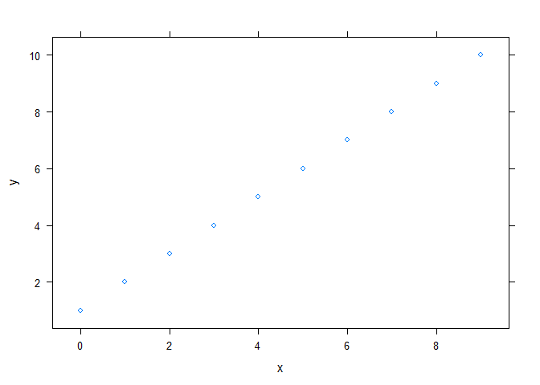

```r
# Figure 1
xyplot(y~x, data = d)
```

To plot this data frame, we’ll use the formula y~x and specify the data frame d. The first argument given is the formula. Formulas in the lattice package can also specify a conditioning variable. The conditioning variable is used to assign data points to different panels.

- plot the same data shown above in two panels, split by the conditioning variable z:

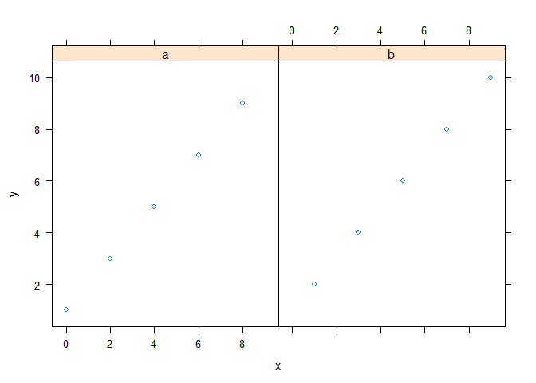

```r
# Figure 2
xyplot(y~x|z, data = d)
```

As you can see, the data is now split into two panels. If you would prefer to see the two data series superimposed on the same plot, you can use the argument groups to specify the grouping variable(s).

- plot the two data series superimposed on the same plot, split by the conditioning variable z:

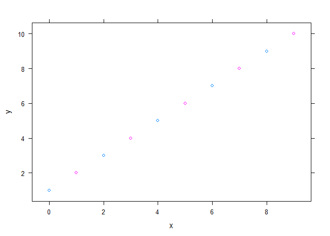

```r
# Figure 3
xyplot(y~x, groups = z, data = d)
```

### 1.1.3 Using Lattice Functions

The easiest way to use lattice graphics is by calling a high-level plotting function. Most of these functions are the equivalent of a similar function in the graphics package. Here is a table showing how standard graphics functions map to lattice functions:

| Graphics package function | Lattice package function | Description |
| --- | --- | --- |
| barplot | barchart | Bar and column charts |
| dotchart | dotplot | Cleveland dot plots |
| hist | histogram | Histograms |
| density | densityplot | Kernel density plots |
| plot.density | densityplot | Kernel density plots |
| stripchart | stripplot | Strip charts |
| xplot | xyplot | Scatter plots |
| pairs | splom | Scatter plot matrices |
| image | levelplot | Image plots |
| contour | contourplot | Contour plots |
| persp | cloud, wireframe | Perspective charts of three-dimensional data |
| – | qqmath | Quantile-quantile plots |
| – | qq | Quantile-quantile plots |

When you call a high-level lattice function, it does not actually plot the data. Instead, each of these functions returns a lattice object. To actually show the graphic, you need to use a print or plot command.

- The lattice object

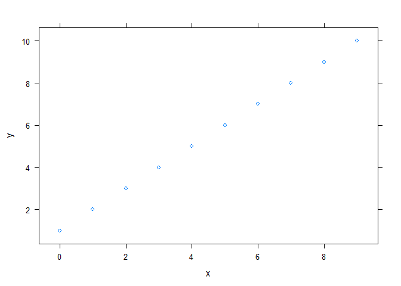

```r
# Figure 4
obj <- xyplot(y~x, data = d)
plot(obj)
```

For some (but not all) lattice functions, it is possible to specify the source data in multiple forms.

- The function `histogram` can accept data arguments as data frames, factors or numeric vectors.

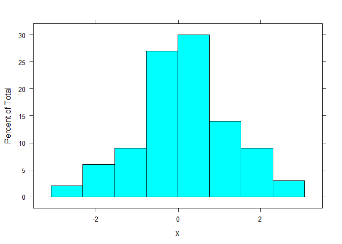

```r
# Figure 5
x = rnorm(100)
histogram(x, data = NULL)
```

Here is a table of data types accepted by different lattice functions:

| Lattice function | Data types |
| --- | --- |
| barchart | Array, formula, matrix, numeric vector, table |
| dotplot | Array, formula, matrix, numeric vector, table |
| histogram | Factor, formula, numeric vector |
| densityplot | Formula, numeric vector |
| stripplot | Formula, numeric vector |
| qqmath | Formula, numeric vector |
| xyplot | Formula |
| qq | Formula |
| splom | Data frame formula, matrix |
| levelplot | Array, formula, matrix, table |
| contourplot | Array, formula, matrix, table |
| cloud | Formula, matrix, table |
| wireframe | Formula, matrix |

For more details on arguments to lattice functions, see the latter section “Customizing Lattice Graphics”.

### 1.1.4 Custom Panel Functions

With standard graphics, you could easily superimpose points, lines, text, and other objects on existing charts. It’s possible to do the same thing with lattice graphics.

In order to add extra graphical elements to a lattice plot, you need to use a custom panel function.

- Add a diagonal line into Figure 2:

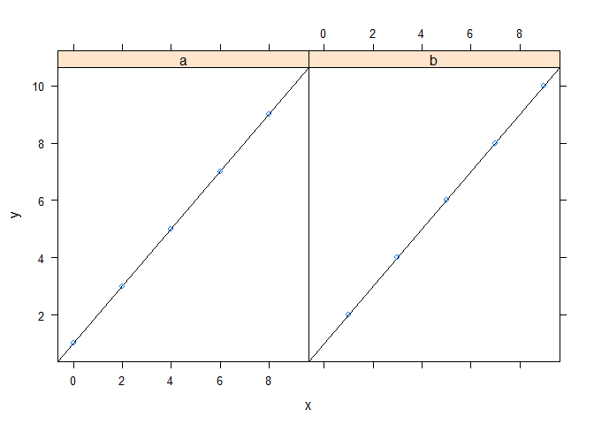

```r
# Figure 6
xyplot(y~x|z,
       data  = d,
       panel = function(...){panel.abline(a = 1, b = 1)
                             panel.xyplot(...)}
)
```

We create a new custom panel function that calls both `panel.xyplot()` and `panel.abline()`. The new panel function will pass along its arguments to `panel.xyplot()`. We specify a line that crosses the y-axis at 1 (through the `a = 1` argument to `panel.abline()`) and has slope 1 (through the `b = 1` argument to `panel.abline()`).

## 1.2 High-Level Lattice Plotting Functions

### 1.2.1 Univariate Trellis Plots

In this section, we use the same data set for most of the examples: births in the United States during 2006. The version that is included in the nutshell package only contains a 10% sample from the original data file. Each record includes the following variables:

| Arguments | Description |
| --- | --- |
| DOB_MM | Month of date of birth |
| DOB_WK | Day of week of birth |
| MAGER | Mother’s age |
| TBO_REC | Total birth order |
| WTGAIN | Weight gain by mother |
| SEX | A factor with levels F M, representing the sex of the child |
| APGAR5 | APGAR score |
| DMEDUC | Mother’s education level |
| UPREVIS | Number of prenatal visits |
| ESTGEST | Estimated weeks of gestation |
| DMETH_REC | Delivery Method |
| DPLURAL | “Plural Births;” levels include 1 Single, 2 Twin, 3 Triplet or higher |
| DBWT | Birth weight, in grams |

You can view this data set with the following codes

```r
# library(nutshell)
data(births2006.smpl)
```

#### 1.2.1.1 Bar Charts

- Calculating a table of the number of births by day of week and then printing a bar chart to show the number of births by day of week:

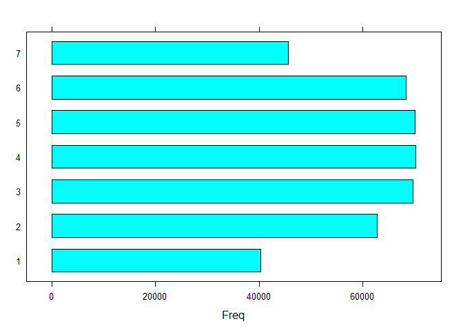

```r
# Figure 7
births.dow <- table(births2006.smpl$DOB_WK)
barchart(births.dow)
```

Notice that many more babies are born on weekdays than on weekends. That’s a little surprising.

You might wonder if there is a difference in the number of births because of the delivery method; maybe doctors just schedule a lot of cesarean sections on weekdays, and natural births occur all the time. This is the type of question that the lattice package is great for answering.

- Eliminate records where the delivery method was unknown and then tabulate the number of births by day of week and method:

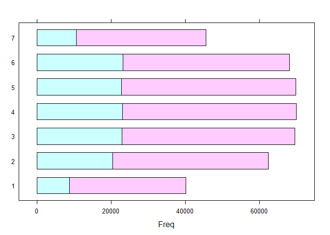

```r
# Figure 8
births2006.dm <- transform(births2006.smpl[births2006.smpl$DMETH_REC != "Unknown", ],
                           DMETH_REC = as.factor(as.character(DMETH_REC)))
dob.dm.tbl <- table(WK = births2006.dm$DOB_WK, MM = births2006.dm$DMETH_REC)
barchart(dob.dm.tbl)
```

By default, barchart prints stacked bars with no legend and the different colors show different groups. But notice that the different shades aren’t labeled, so it’s not immediately obvious what each shade represents. Let’s try to change the way the chart is displayed.

- Unstack the bars (`stack = FALSE`) and add a legend (`auto.key = TRUE`):

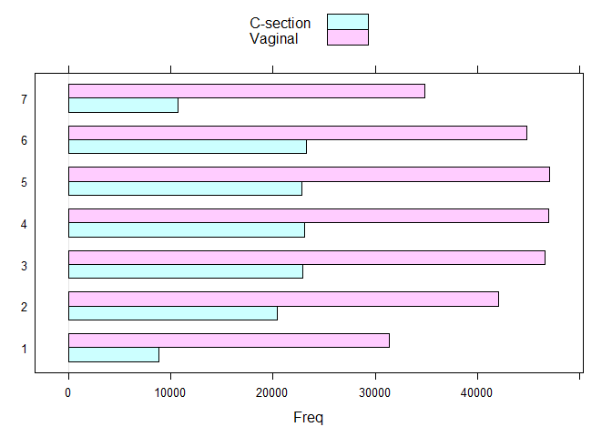

```r
# Figure 9
barchart(dob.dm.tbl, stack = FALSE, auto.key = TRUE)
```

It’s a little easier to see that both types of births decrease on weekends, but it’s still a little difficult to compare values within each group. So let’s try a different approach.

- Split bars into two different panels by telling barchart not to group by color (`groups = FALSE`) and change to columns (`horizontal=FALSE`)

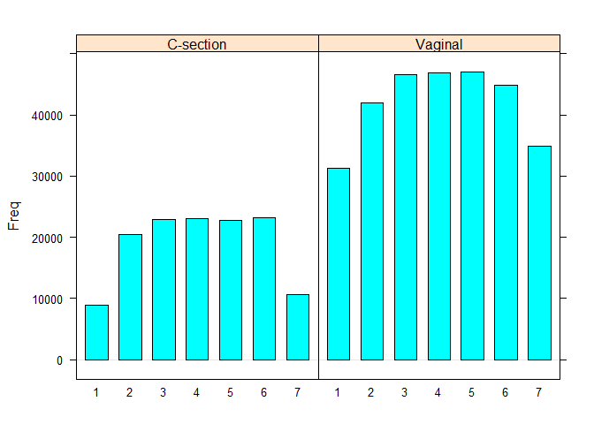

```r
# Figure 10
barchart(dob.dm.tbl, groups = FALSE, horizontal = FALSE)
```

The two different charts are in different panels. Now, we can more clearly see what’s going on. The number of vaginal births decreases on weekends, by maybe 25 to 30%. However, C-sections drop by 50 to 60%. As you can see, lattice graphics let you quickly try different ways to present information, helping you zero in on the method that best illustrates what is happening in the data.

#### 1.2.1.2 Dot plots

Like bar charts, dot plots are useful for showing data where there is a single point for each category, especially when we’re going to summarize larger data tables. For example, let’s look at a chart of data on births by day of week. Is the pattern we saw above a seasonal pattern?

- Create a new table counting births by month, week, and delivery method and then plot the results using a dot plot:

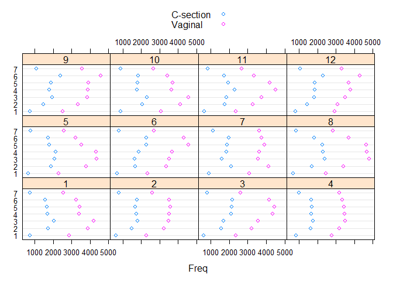

```r
# Figure 11
dob.dm.tbl.alt <- table(WEEK = births2006.dm$DOB_WK,
                        MONTH = births2006.dm$DOB_MM,
                        METHOD = births2006.dm$DMETH_REC)
dotplot(dob.dm.tbl.alt,
        stack    = FALSE,
        auto.key = TRUE,
        groups   = TRUE
        )
```

In this plot, we keep on grouping, so that different delivery methods are shown in different colors (`groups = TRUE`). To help highlight differences, we’ll disable stacking values (`stack = FALSE`). Finally, we’ll print a key so that it’s obvious what each symbol represents (`auto.key = TRUE`).

As you can see, there are slight seasonal differences, but the overall pattern remains the same.

As another example of dot plots, let’s look at the tire failure data in the nutshell package. In 2003, the National Highway Traffic Safety Administration (NHTSA) began a study into the durability of radial tires on light trucks. (See [this](http://www.nhtsa.gov/portal/site/nhtsa/menuitem.8027fe7cfb6e727568d07a30343c44cc/) for links to this study.) Tests were carried out on six different types of tires. Here is a table of the characteristics of the tires:

| Tire | Size | Load Index | Speed Rating | Brand | Model | OE Vehicle | OE Model |
| --- | --- | --- | --- | --- | --- | --- | --- |
| B | P195/65R15 | 89 | S | BF Goodrich | Touring T/A | Chevy | Cavalier |
| C | P205/65R15 | 92 | V | Goodyear | Eagle GA | Lexus | ES300 |
| D | P235/75R15 | 108 | S | Michelin | LTX M/S | Ford,Dodge | E 150 Van, Ram Van 1500 |
| E | P265/75R16 | 114 | S | Firestone | Wilderness AT | Chevy/GMC | Silverado, Tahoe, Yukon |
| H | LT245/75R16/E | 120/116 | Q | Pathfinder | ATR A/S OWL | NA | NA |
| L | 255/65R16 | 109 | H | General | Grabber ST A/S | Mercedes | ML320 |

We focus on only three variables. **Time_To_Failure** is the time before each tire failed (in hours), **Speed_At_Failure_km_h** is the testing speed at which the tire failed, and **Tire_Type** is the type of tire tested. We know that tests were only run at certain stepped speeds; despite the fact that speed is a numeric variable, we can treat it as a factor.

- Show the one continuous variable (**time to failure**) by the speed at failure for each different type of tire

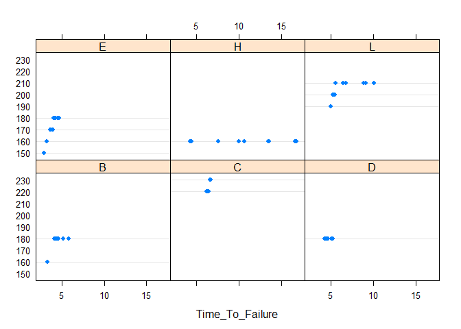

```r
# Figure 12
library(nutshell)
data(tires.sus)
dotplot(as.factor(Speed_At_Failure_km_h)~Time_To_Failure|Tire_Type, data = tires.sus)
```

This diagram let’s us clearly see how quickly tires failed in each of the tests. For example, all type D tires failed quickly at the testing speed of 180 km/h, but some type H tires lasted a long time before failure.

#### 1.2.1.3 Histograms

The histogram is a very popular chart for showing the distribution of a variable. As an example of histograms, let’s look at average birth weights, grouped by number of births.

- Show the distribution of average birth weights, split by the number of births:

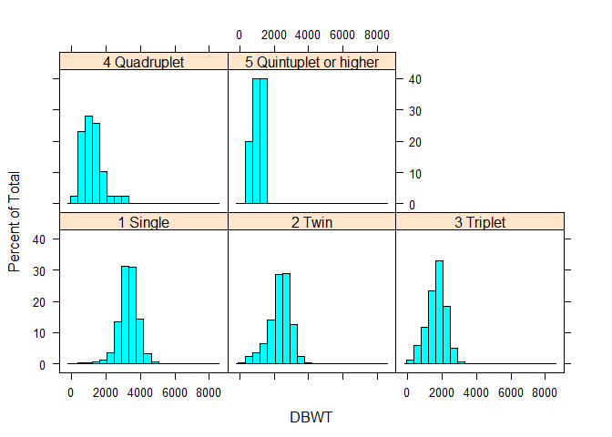

```r
# Figure 13
histogram(~DBWT|DPLURAL, data = births2006.smpl)
```

This format helps make each chart readable by itself, but makes it difficult to compare the different groups.

- Stack the charts on top of each other using the layout variable:

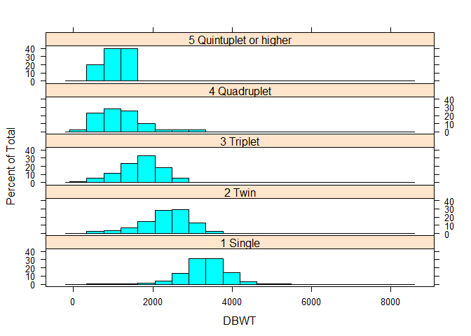

```r
# Figure 14
histogram(~DBWT|DPLURAL, data = births2006.smpl, layout = c(1, 5))
```

It’s easy to see that birth weights are roughly normally distributed within each group, but the mean weight drops as the number of births increases.

#### 1.2.1.4 Density plots

If you’d like to see a single line showing the distribution, instead of a set of columns representing bins, you can use kernel density plots.

- Redraw the example above and replace the histogram with a density plot:

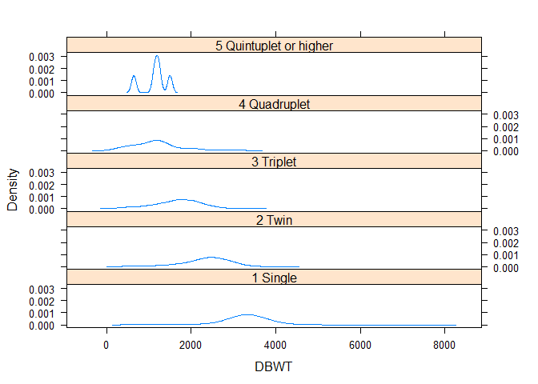

```r
# Figure 15
densityplot(~DBWT|DPLURAL,
            data   = births2006.smpl,
            layout = c(1, 5),
            plot.points = FALSE
            )
```

By default, densityplot will draw a strip chart under each chart, showing every data point. However, the data set is so big, we specify `plot.points = FALSE`.

One advantage of density plots over histograms is that you can stack them on top of each other and still read the results.

- Change the conditioning variable (**DPLURAL**) to a grouping variable so that we can stack these charts on top of each other:

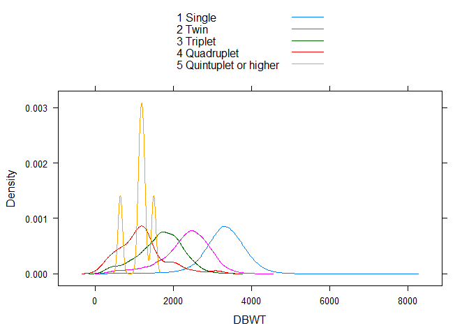

```r
# Figure 16
densityplot(~DBWT,
            groups   = DPLURAL,
            data     = births2006.smpl,
            plot.points = FALSE,
            auto.key = TRUE
            )
```

As you can see, it’s easier to compare distribution shapes (and centers) by superimposing the charts.

#### 1.2.1.5 Strip plots

A good alternative to histograms are strip plots, especially when there isn’t much data to plot. Strip plots look similar to dot plots, but they show different information. Dot plots are designed to show one value per category (often a mean or a sum), while strip plots show many values. You can think of strip plots as one-dimensional scatter plots.

As an example of a strip plot, let’s look at the weights of babies born in sets of 4 or more. There were only 44 observations in our data set that match this description.

- Use the subset argument to specify two sets of observations, and add some random vertical noise to make the points easier to read (`jitter.data = TRUE`):

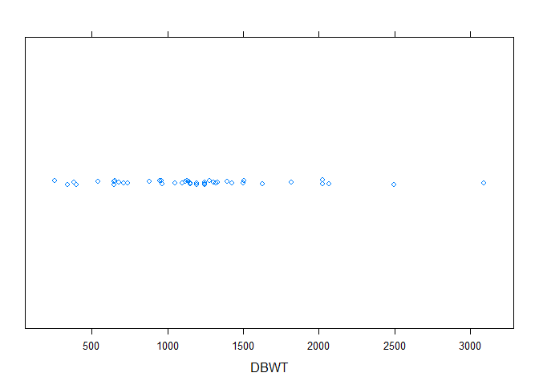

```r
# Figure 17
stripplot(~DBWT,
          data   = births2006.smpl,
          subset = (DPLURAL == "5 Quintuplet or higher"  | DPLURAL == "4 Quadruplet"),
          jitter.data = TRUE
          )
```

#### 1.2.1.6 Univariate quantile-quantile plots

A quantile-quantile plot is a useful plot that can compare the distribution of actual data values to a theoretical distribution. It plots quantiles of the observed data against quantiles of a theoretical distribution. If the plotted points form a straight diagonal line (from top right to bottom left), then it is likely that the observed data comes from the theoretical distribution. Quantile-quantile plots are a very powerful technique for seeing how closely a data set matches a theoretical distribution (or how much it deviates from it).

- Plot 100,000 random values from a normal distribution to show what qqmath does:

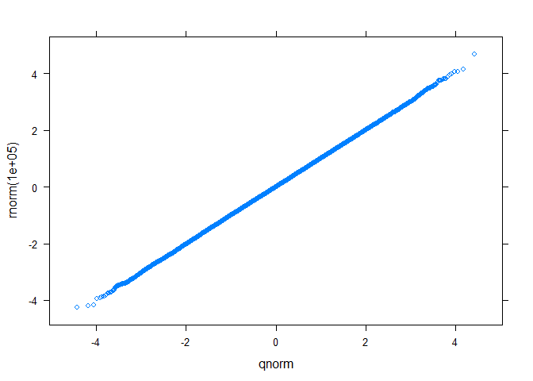

```r
# Figure 18
qqmath(rnorm(100000))
```

- Plot a set of quantile-quantile plots for a random sample of 50,000 points from the birth weight data:

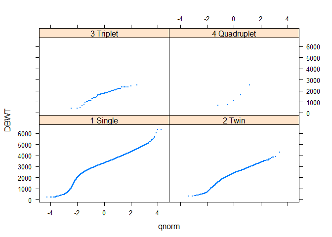

```r
# Figure 19
qqmath(~DBWT|DPLURAL,
       data   = births2006.smpl[sample(1:nrow(births2006.smpl), 50000), ],
       pch    = 19,
       cex    = 0.25,
       subset = (DPLURAL != "5 Quintuplet or higher")
       )
```

As you can see from above figure, the distribution of birth weights is not quite normal.

As another example, let’s look at real estate prices in San Francisco in 2008 and 2009. This data set is included in the nutshell package as **sanfrancisco.home.sales**.

- Show the difference of the distribution of real estate prices and normal distribution

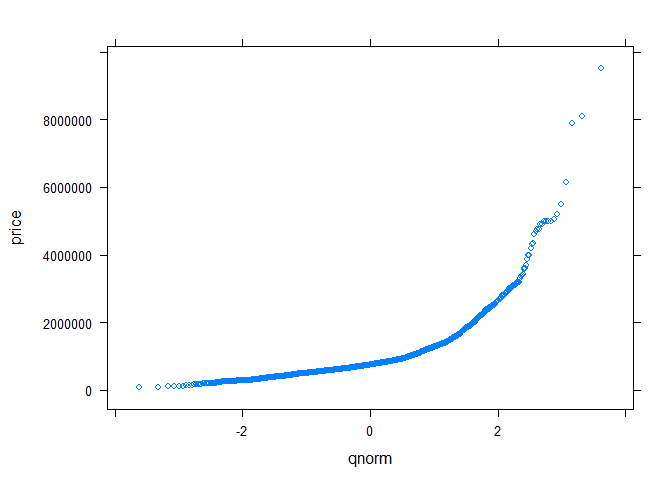

```r
# Figure 20
library(nutshell)
data(sanfrancisco.home.sales)
qqmath(~price, data = sanfrancisco.home.sales)
```

As expected, real estate prices is not normally distributed. Intuitively, it doesn’t make sense for real estate prices to be normally distributed. There are far more people with below-average incomes than above-average incomes. The lowest recorded price in the data set is $100,000; the highest is $9,500,000.

But it looks exponential, so let’s try a log transform.

- Determine whether log-transformed data is normally distributed or not:

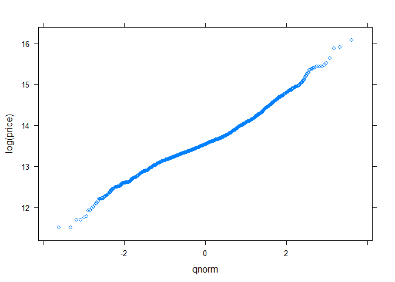

```r
# Figure 21
qqmath(~log(price), data = sanfrancisco.home.sales)
```

A log transform yields a distribution that looks pretty close to normally distributed.

Then let’s take a look at how the distribution changes based on the number of bedrooms.

- Plot smooth lines (`type = "smooth"`) to show how the distribution changes based on the number of bedrooms (`groups = bedrooms`):

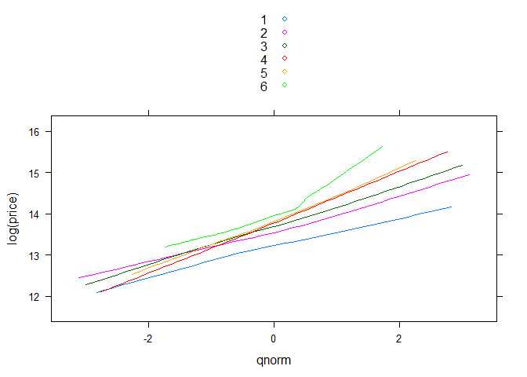

```r
# Figure 22
qqmath(~log(price),
       groups   = bedrooms,
       data     = subset(sanfrancisco.home.sales,
                         !is.na(bedrooms) & bedrooms>0 & bedrooms<7),
       auto.key = TRUE,
       drop.unused.levels = TRUE,
       type     = "smooth"
       )
```

In this formula, we pass an explicit subset as an argument to the function instead of using the `subset` argument. Notice that the lines are separate, with higher values for higher numbers of bedrooms. `drop.unused.levels` is a logical flag indicating whether the unused levels of factors will be dropped.

We can do the same thing for square footage.

- Show how the distribution changes based on square footage.

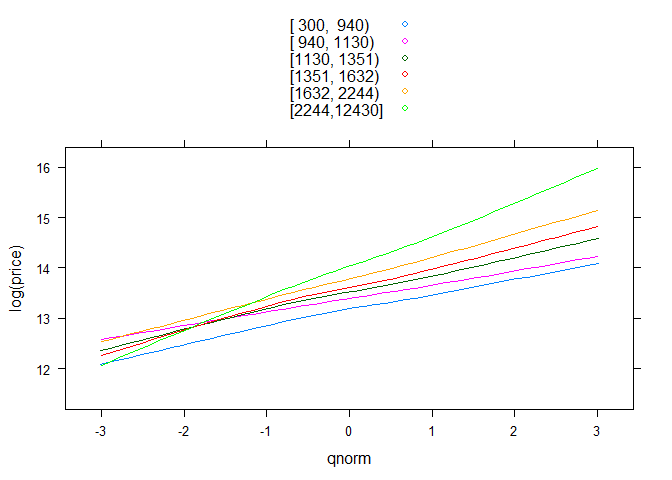

```r
# Figure 23
# library(Hmisc)
qqmath(~log(price),
       groups   = cut2(squarefeet, g = 6),
       data     = subset(sanfrancisco.home.sales, !is.na(squarefeet)),
       auto.key = TRUE,
       drop.unused.levels = TRUE,
       type     = "smooth"
       )
```

The function `cut2` from the package HMisc to divide square footages into six even quantiles.

### 1.2.2 Bivariate Trellis Plots

This section describes Trellis plots for plotting two variables. Many real data sets (for example, financial data) record relationships between multiple numeric variables.

#### 1.2.2.1 Scatter plots

As an example of a scatter plot, let’s take a look at the relationship between house size and price.

- Show size and price:

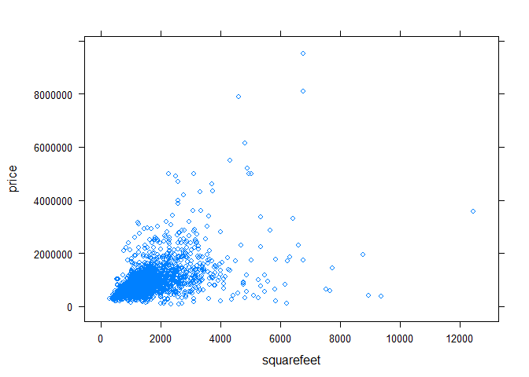

```r
# Figure 24
xyplot(price~squarefeet, data = sanfrancisco.home.sales)
```

It looks like there is a rough correspondence between size and price (the plot looks vaguely cone shaped). Let’s analyze it further.

- Show how this relationship varies by zip code. Trim outliers (sales prices over 4,000,000 and properties over 6,000 square feet) using the subset argument.

```r
table(subset(sanfrancisco.home.sales, !is.na(squarefeet), select = zip))
```

```
##
## 94100 94102 94103 94104 94105 94107 94108 94109 94110 94111 94112 94114
##     2    52    62     4    44   147    21   115   161    12   192   143
## 94115 94116 94117 94118 94121 94122 94123 94124 94127 94131 94132 94133
##   101   124   114    92    92   131    71    85   108   136    82    47
## 94134 94158
##   105    13
```

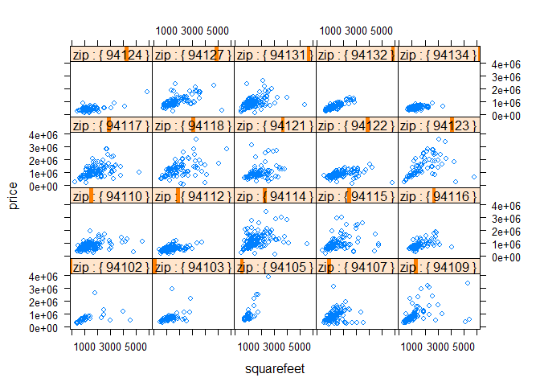

```r
# Figure 25
xyplot(price~squarefeet|zip,
       data = sanfrancisco.home.sales,
       subset = (zip!=94100 & zip!=94104 & zip!=94108 & zip!=94111 &
                 zip!=94133 & zip!=94158 & price<4000000 &
                 ifelse(is.na(squarefeet), FALSE, squarefeet<6000)),
       strip = strip.custom(strip.levels = TRUE)
       )
```

The first formula is to pick a subset of zip codes to plot. A few parts of the city are sparsely populated (like the financial district, 94104) and don’t have enough data to make plotting interesting. `strip.custom()` is the function that draws the strips by specifying certain arguments. `strip.levels()` is a logical vector of length 2, indicating whether or not the level of the conditioning variable is to be written on the strip.

Now, the linear relationship is much more pronounced. We can notice that the different slopes in different neighborhoods. We can make this slightly more readable by using neighborhood names.

- Rerun the code, conditioning by neighborhood. Add a diagonal line to each plot (through a custom panel function). Change the default points plotted to be solid (`pch = 19`) and shrink them to a smaller size (`cex=.2`):

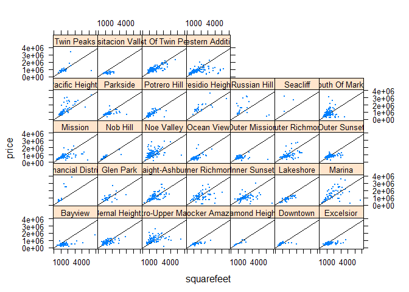

```r
# Figure 26
dollars.per.squarefoot <- mean(
  sanfrancisco.home.sales$price / sanfrancisco.home.sales$squarefeet,
  na.rm = TRUE)
xyplot(price~squarefeet|neighborhood,
       data   = sanfrancisco.home.sales,
       pch    = 19,
       cex    = .2,
       subset = (zip!=94100 & zip!=94104 & zip!=94108 & zip!=94111 &
                 zip!=94133 & zip!=94158 & price<4000000 &
                 ifelse(is.na(squarefeet), FALSE, squarefeet<6000)),
       strip  = strip.custom(strip.levels   = TRUE,
                             horizontal     = TRUE,
                             par.strip.text = list(cex = .8)),
       panel  = function(...) {panel.abline(a = 0, b = dollars.per.squarefoot)
                               panel.xyplot(...)}
       )
```

#### 1.2.2.2 Box plots

Box plots in the lattice package are just like box plots drawn with the graphics package. The boxes represent prices from the 25th through the 75th percentiles (the interquartile range), the dots represent median prices, and the whiskers represent the minimum or maximum values. (When there are values that stretch beyond 1.5 times the length of the interquartile range, the whiskers are truncated at those extremes.)

Let’s take a look at how the San Francisco home prices changed over time. We can use box plots to watch how the whole distribution changed in this period.

- Show the distribution of sales prices by month

```r
# Figure 27
table(cut(sanfrancisco.home.sales$date, "month"))
```

```
##
## 2008-02-01 2008-03-01 2008-04-01 2008-05-01 2008-06-01 2008-07-01
##        139        230        267        253        237        198
## 2008-08-01 2008-09-01 2008-10-01 2008-11-01 2008-12-01 2009-01-01
##        253        223        272        118        181        114
## 2009-02-01 2009-03-01 2009-04-01 2009-05-01 2009-06-01 2009-07-01
##        123        142        116        180        150         85
```

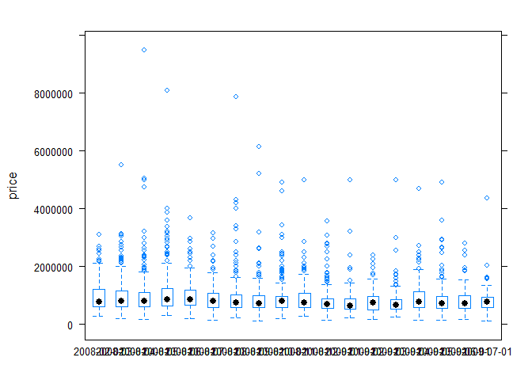

```r
bwplot(price~cut(date, "month"), data = sanfrancisco.home.sales)
```

Unfortunately, this doesn’t produce an easily readable plot and there are a large number of outliers that are making the plot hard to see. Let’s try plotting the box plots again, this time with the logtransformed values. To make it more readable, we can change to vertical box plots and rotate the text at the bottom:

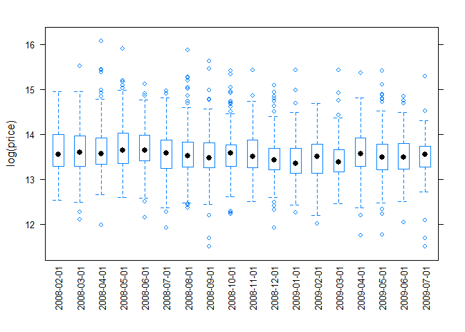

```r
# Figure 28
bwplot(log(price)~cut(date, "month"),
       data   = sanfrancisco.home.sales,
       scales = list(x = list(rot = 90))
       )
```

#### 1.2.2.3 Scatter plots matrices

If you would like to generate a matrix of scatter plots for many different pairs of variables, you can use the `splom` function.

- Show the relationships between four variables in the iris data set, splited by species. (you will see 16 subgraphs)

```r
head(iris)
```

| Sepal.Length | Sepal.Width | Petal.Length | Petal.Width | Species |
| --- | --- | --- | --- | --- |
| 5.1 | 3.5 | 1.4 | 0.2 | setosa |
| 4.9 | 3.0 | 1.4 | 0.2 | setosa |
| 4.7 | 3.2 | 1.3 | 0.2 | setosa |
| 4.6 | 3.1 | 1.5 | 0.2 | setosa |
| 5.0 | 3.6 | 1.4 | 0.2 | setosa |
| 5.4 | 3.9 | 1.7 | 0.4 | setosa |

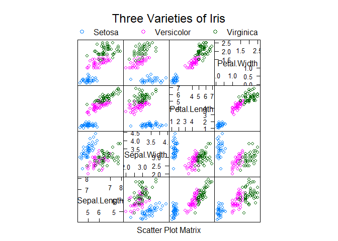

```r
# Figure 29
super.sym <- trellis.par.get("superpose.symbol")
splom(~iris[1:4], groups = Species, data = iris,
      panel = panel.superpose,
      key   = list(title   = "Three Varieties of Iris",
                   columns = 3,
                   points  = list(pch = super.sym$pch[1:3],
                   col     = super.sym$col[1:3]),
                   text    = list(c("Setosa", "Versicolor", "Virginica")))
      )
```